# Detroit City Council Remarks

Eric Langowski

9/15/2022

# 1 Recent Improvements

## 1.1 Median Ratio Falls Below 50%

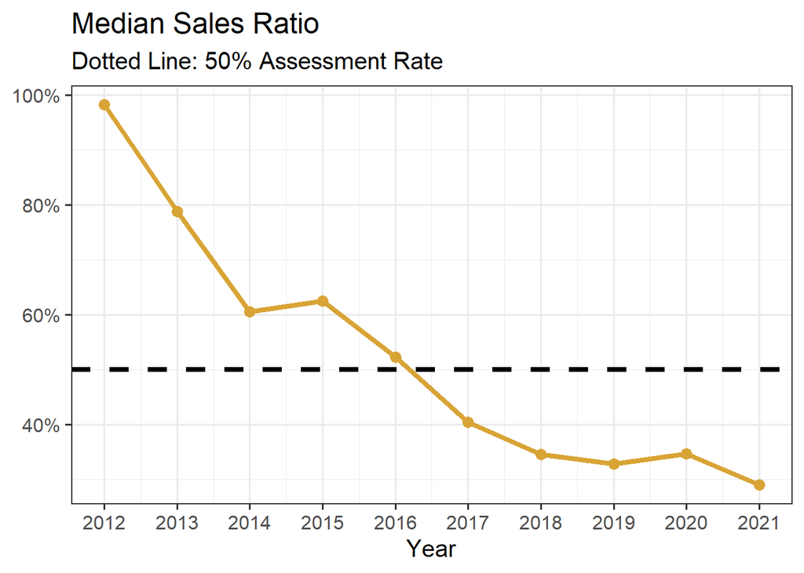

## 1.2 Extreme Overassessment (50% or higher) Falls

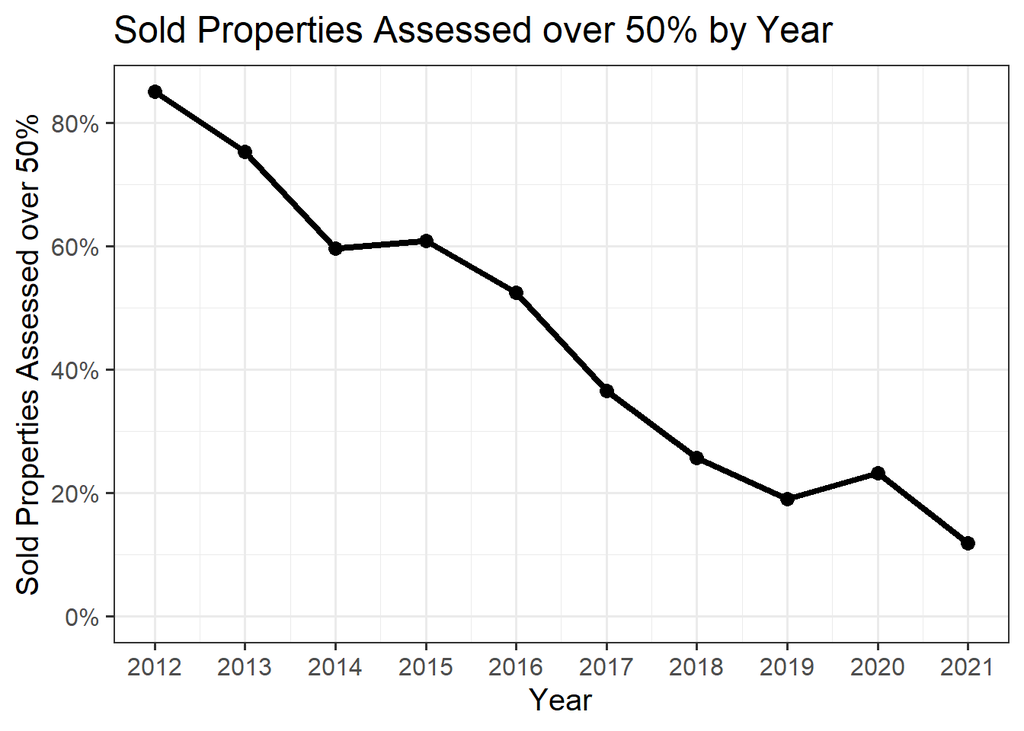

## 1.3 Industry Standards Improve But Still Not Met

Note: the City of Detroit supports the use of these specific industry-accepted standards, including language from [this resolution](https://detroitmi.gov/sites/detroitmi.localhost/files/2020-06/Resolution%20Urging%20the%20State%20Tax%20Commission%20to%20Modify%20Assessing%20Guideline.pdf).

### 1.3.1 Coefficient of Dispersion (COD)

The COD is a measure of assessment uniformity, or horizontal equity. It is the average absolute percentage difference from the median sales ratio. For instance, a COD of 10 means that properties have ratios that on average deviate by 10 percent from the median ratio. The IAAO specifies that the acceptable range for COD is below 15.

For 2021, the COD in Detroit was 34.58 which **did not meet** the IAAO standard for uniformity.

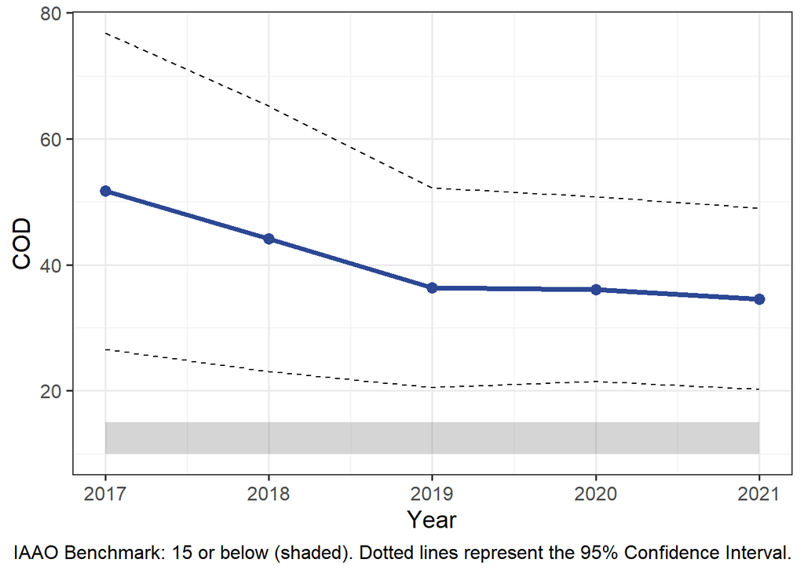

### 1.3.2 Price-Related Differential (PRD)

The Price-Related Differential (PRD) measures vertical equity, which is whether the City taxes homes of different values at the same rate, regardless of sales prices. In 2021, the PRD in Detroit, was 1.01 which **meets** the IAAO standard for vertical equity.

[figure not shown]

### 1.3.3 Coefficient of Price-Related Bias (PRB)

The Price-Related Bias (PRB) is another way of measuring vertical equity, which is whether the City taxes homes of different values at the same rate.

In 2021, the PRB in Detroit was -0.143 which indicates that sales ratios decrease by 14.3% when home values double. This **does not meet** the IAAO standard.

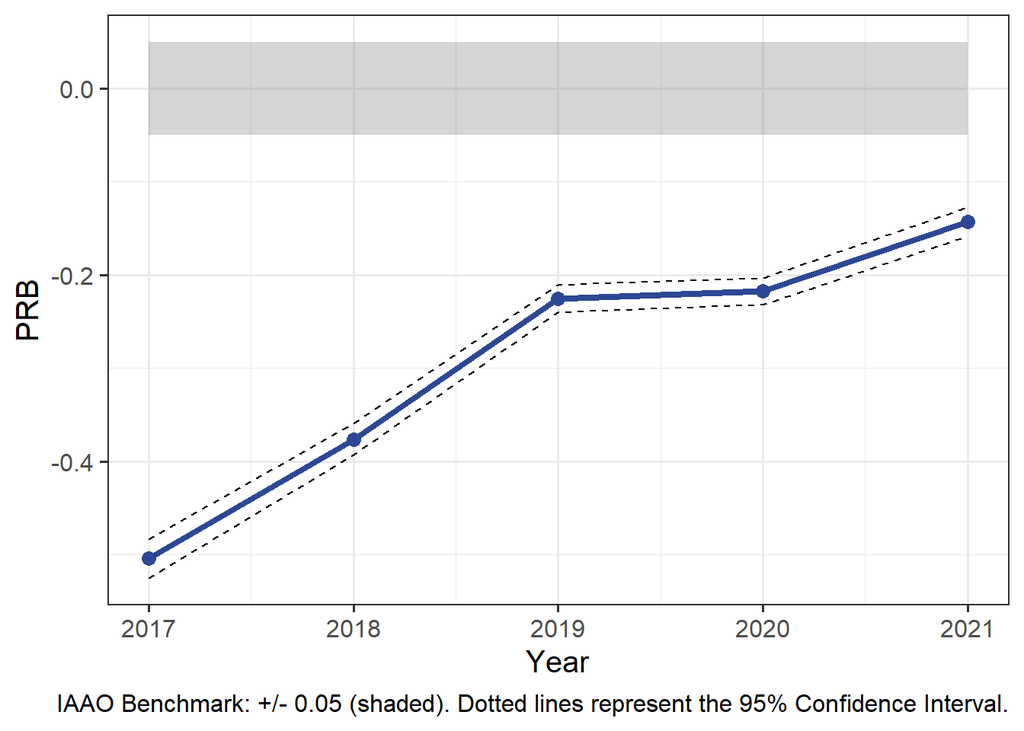

# 2 Remaining Issues

## 2.1 Regressivity

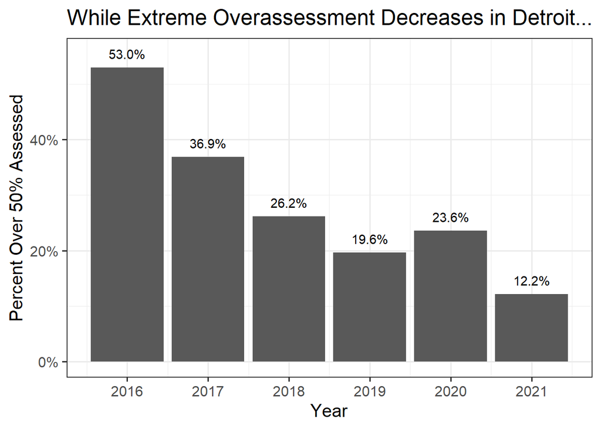

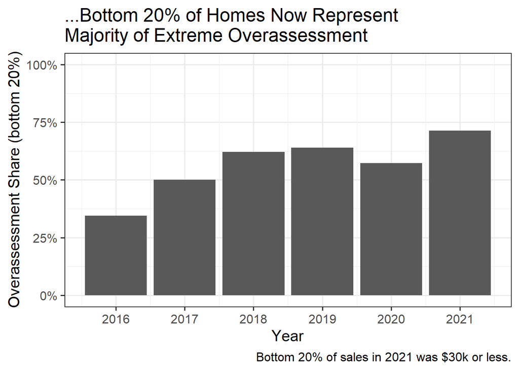

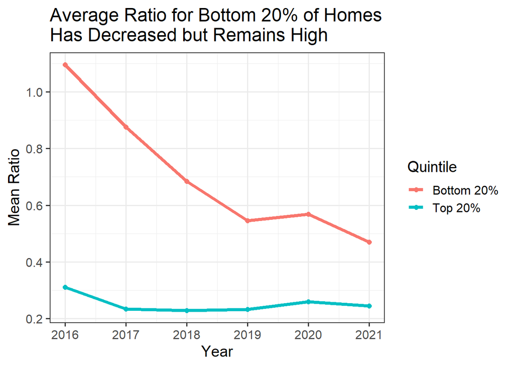

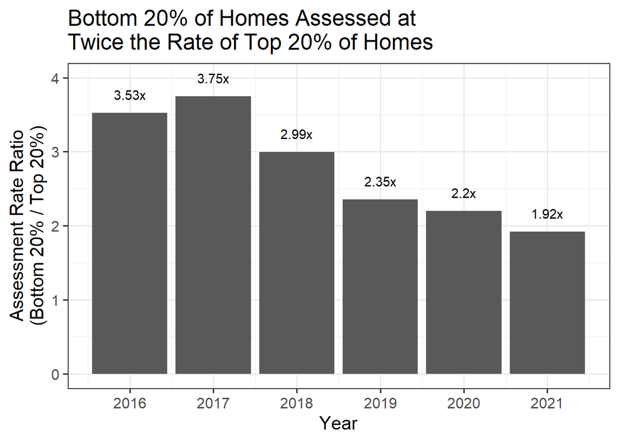

## 2.2 Higher Valued Properties are Underassessed

In 2021, the most expensive homes (the top decile) were assessed at 25.3% of their value and the least expensive homes (the bottom decile) were assessed at 50.7%. In other words, the least expensive homes were assessed at **2.01 times** the rate applied to the most expensive homes. Across our sample from 2019 to 2021, the most expensive homes were assessed at 24.5% of their value and the least expensive homes were assessed at 56.6%, which is **2.31 times** the rate applied to the most expensive homes.

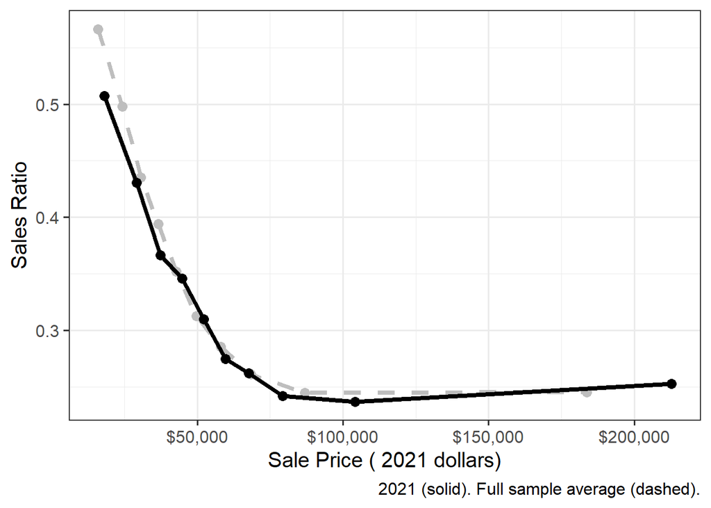

## 2.3 Across Neighborhood Areas/Economic Condition Factors (ECFs)

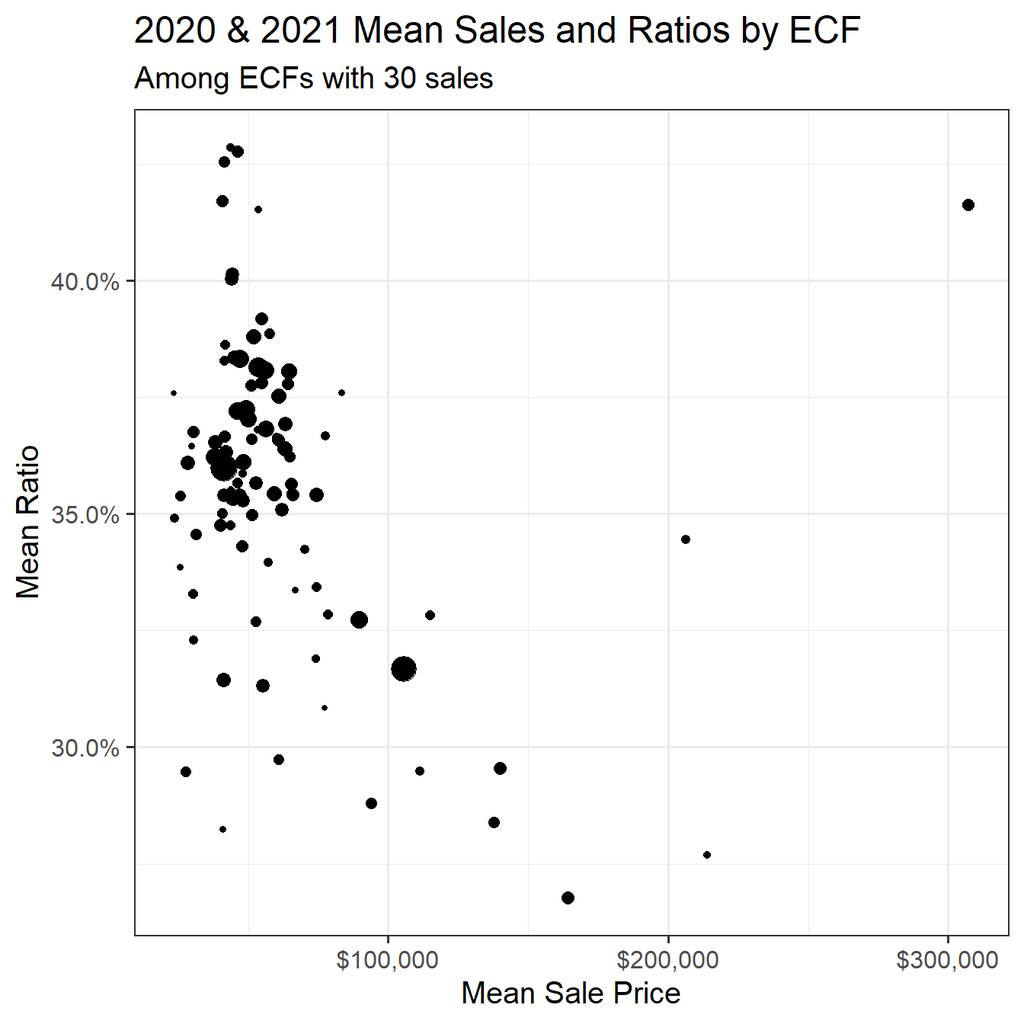

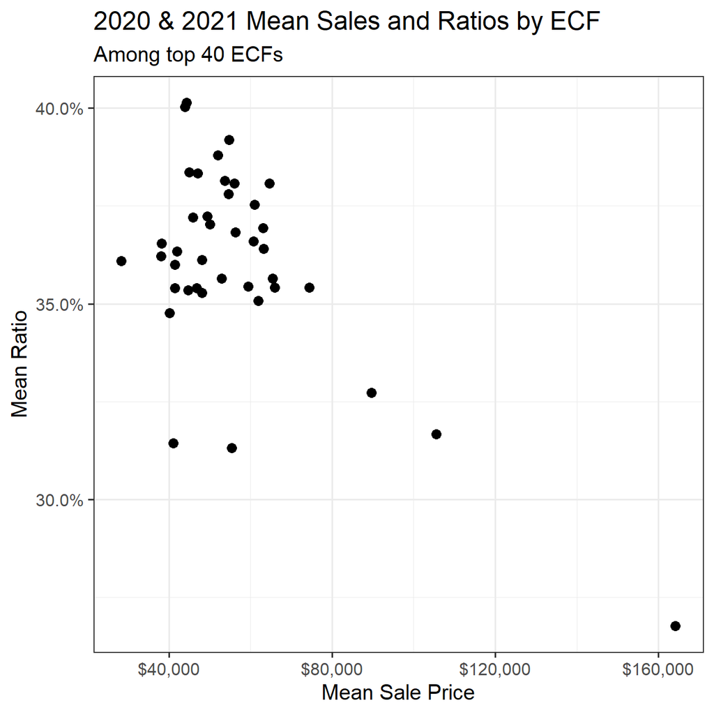

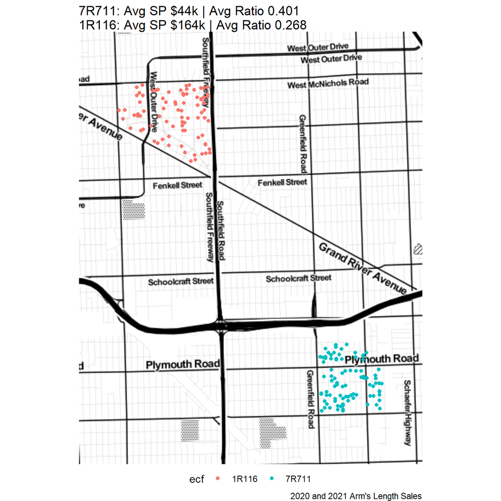

# 3 Data Notes

Uses assessment data from two FOIA requests and sales data from the Detroit Open Data portal. Sales were included only if properties had taxable status, sold for greater than $1000, and were marked as Valid Arms Length Transactions by the Assessor. The IAAO arms length standard was then applied to these sales. This produces a conservative estimate of regressivity since data is doubly filtered. Limited data is available in 2011 and 2021.